# Data Science II - Assignment

Alexandra Salo

# Dataset description

## Load packages and data

```r
knitr::opts_chunk$set(echo = TRUE)
library(tidyverse)
```

```r
library(ggplot2)
library(data.table)
library(ggpubr)
library(DataExplorer)
library(dplyr)
library(corrplot)
library(glmnet)
library(caret)
library(pscl)
library(MASS)
library(AER)
library(magrittr)
knitr::opts_chunk$set(echo = TRUE)
df<-fread("census_section_stats.csv", sep=";", dec=",", stringsAsFactors = F)
head(df)
```

```
##    index census_section_code census_district_code city_code province_code
## 1:     0          2807915077              2807915     28079            28
## 2:     1          2807911153              2807911     28079            28
## 3:     2          2807912045              2807912     28079            28
## 4:     3          2807912028              2807912     28079            28
## 5:     4          2807912037              2807912     28079            28
## 6:     5          2807912008              2807912     28079            28
##          area                                     centroid population
## 1: 0.03106851 POINT (445950.10837580997 4475766.441625915)       1073
## 2: 0.03689683  POINT (435897.6843577322 4468991.370699024)       1578
## 3: 0.03168443 POINT (440254.6396935178 4470484.3928486835)       1793
## 4: 0.01147211 POINT (441426.03395814047 4469702.549072934)        911
## 5: 0.04474097  POINT (441515.5287670559 4468906.541133046)       1324
## 6: 0.04552570   POINT (439391.811371995 4469340.731671609)       1226
##    family_income income_per_capita  avg_age   spanish foreigners   europeans
```

[output cut: 83 more lines]

```r
df <- df %>%
  as.data.frame() %>%
  dplyr::select(-centroid, -census_section_code, -geometry)
```

For every census section we have a row in our dataset, here are some of the main columns of the dataset:

* census_section_code: census_section_code identifier

* n_pharmacies (target variable 1): number of pharmacies in the census section

* n_schools (target variable 2): number of schools in the census section

* n_transport_salespoints: number of transport points of sale.

# Descriptive analysis

## Plots and other interesting figures

```r
knitr::opts_chunk$set(echo = TRUE)

summary(df)
```

```
##      index      census_district_code   city_code     province_code
##  Min.   :   0   Min.   :2800101      Min.   :28001   Min.   :28
##  1st Qu.:1103   1st Qu.:2807901      1st Qu.:28079   1st Qu.:28
##  Median :2206   Median :2807910      Median :28079   Median :28
##  Mean   :2206   Mean   :2808268      Mean   :28083   Mean   :28
##  3rd Qu.:3310   3rd Qu.:2807918      3rd Qu.:28079   3rd Qu.:28
##  Max.   :4413   Max.   :2890301      Max.   :28903   Max.   :28
##       area             population   family_income   income_per_capita
##  Min.   :  0.00594   Min.   :  47   Min.   :12537   Min.   : 3719
##  1st Qu.:  0.02962   1st Qu.:1075   1st Qu.:27842   1st Qu.:10580
##  Median :  0.05510   Median :1381   Median :34314   Median :13046
##  Mean   :  1.81802   Mean   :1490   Mean   :39489   Mean   :14798
##  3rd Qu.:  0.17587   3rd Qu.:1816   3rd Qu.:45429   3rd Qu.:17523
##  Max.   :180.87857   Max.   :4004   Max.   :91933   Max.   :32242
##     avg_age         spanish         foreigners        europeans
##  Min.   :25.54   Min.   :0.5293   Min.   :0.00000   Min.   :0.00000
##  1st Qu.:40.26   1st Qu.:0.8267   1st Qu.:0.06844   1st Qu.:0.02225
##  Median :43.48   Median :0.8870   Median :0.11302   Median :0.03463
##  Mean   :42.81   Mean   :0.8723   Mean   :0.12773   Mean   :0.04296
##  3rd Qu.:46.11   3rd Qu.:0.9316   3rd Qu.:0.17327   3rd Qu.:0.05170
##  Max.   :65.80   Max.   :1.0000   Max.   :0.47070   Max.   :0.37260
##     germans            bulgarian            french            italian
##  Min.   :0.0000000   Min.   :0.000000   Min.   :0.000000   Min.   :0.000000
##  1st Qu.:0.0000000   1st Qu.:0.000000   1st Qu.:0.000000   1st Qu.:0.001131
##  Median :0.0005139   Median :0.001415   Median :0.000800   Median :0.002936
##  Mean   :0.0011480   Mean   :0.003190   Mean   :0.002043   Mean   :0.004480
##  3rd Qu.:0.0014967   3rd Qu.:0.004183   3rd Qu.:0.002249   3rd Qu.:0.005994
##  Max.   :0.0425532   Max.   :0.071467   Max.   :0.121133   Max.   :0.037788
##      polish           portuguese           british             romanian
##  Min.   :0.000000   Min.   :0.0000000   Min.   :0.0000000   Min.   :0.00000
##  1st Qu.:0.000000   1st Qu.:0.0004852   1st Qu.:0.0000000   1st Qu.:0.00525
##  Median :0.001106   Median :0.0014996   Median :0.0006845   Median :0.01401
##  Mean   :0.002248   Mean   :0.0022547   Mean   :0.0014827   Mean   :0.02417
##  3rd Qu.:0.003012   3rd Qu.:0.0032338   3rd Qu.:0.0018325   3rd Qu.:0.02950
##  Max.   :0.134831   Max.   :0.0243902   Max.   :0.0221354   Max.   :0.36619
##   non_european         russian             ukranian           african
##  Min.   :0.000000   Min.   :0.0000000   Min.   :0.000000   Min.   :0.000000
##  1st Qu.:0.001590   1st Qu.:0.0000000   1st Qu.:0.000000   1st Qu.:0.002641
##  Median :0.003870   Median :0.0000000   Median :0.001483   Median :0.007803
##  Mean   :0.005906   Mean   :0.0006801   Mean   :0.003688   Mean   :0.015732
```

[output cut: 57 more lines]

```
##  Max.   :68.325     Max.   :100.000          Max.   :99.366
##     altitude      city_population   population_density   n_pharmacies
##  Min.   : 467.0   Min.   :     47   Min.   :     1.06   Min.   :0.0000
##  1st Qu.: 657.0   1st Qu.: 128256   1st Qu.:  9194.66   1st Qu.:0.0000
##  Median : 657.0   Median :3223334   Median : 24941.68   Median :1.0000
##  Mean   : 667.7   Mean   :1832968   Mean   : 26806.53   Mean   :0.6613
##  3rd Qu.: 660.0   3rd Qu.:3223334   3rd Qu.: 41233.71   3rd Qu.:1.0000
##  Max.   :1433.0   Max.   :3223334   Max.   :113560.50   Max.   :5.0000
##    n_schools       n_transport_salespoints pcg_foreigners
##  Min.   : 0.0000   Min.   :0.0000          Min.   : 0.000
##  1st Qu.: 0.0000   1st Qu.:0.0000          1st Qu.: 6.844
##  Median : 0.0000   Median :0.0000          Median :11.302
##  Mean   : 0.9076   Mean   :0.2707          Mean   :12.773
##  3rd Qu.: 1.0000   3rd Qu.:0.0000          3rd Qu.:17.327
##  Max.   :12.0000   Max.   :4.0000          Max.   :47.070
```

```r
create_report(df)
```

```
##
##
## processing file: report.rmd
```

[output not shown]

```
## output file: /Users/alexandrasalo/Desktop/Statistics and Data Science II/report.knit.md
```

[output not shown]

```
##
## Output created: report.html
```

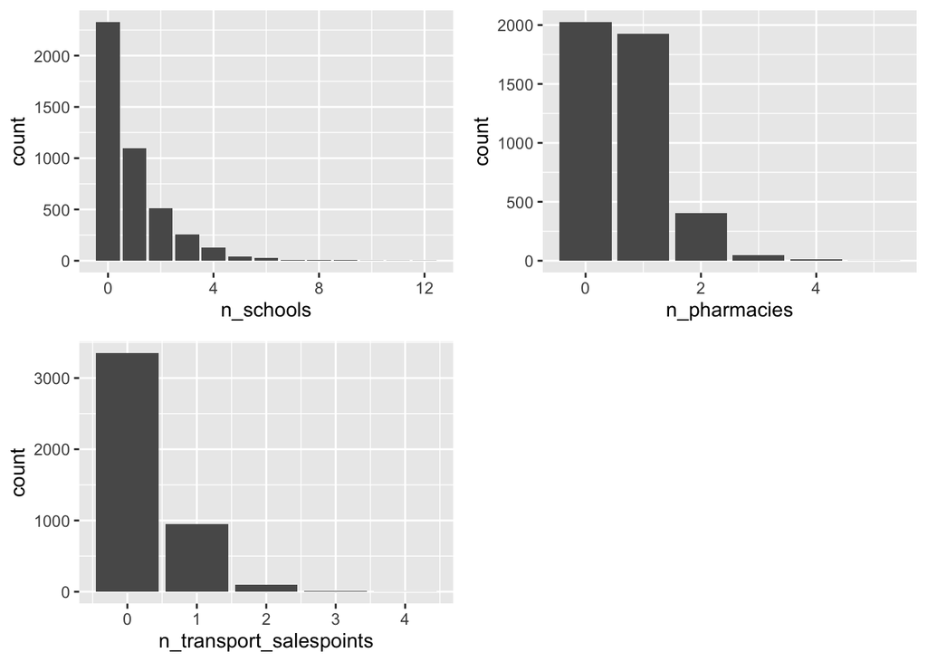

```r
#lets highlight the target variables
plot1 <- ggplot(df, aes(n_schools)) +
  geom_bar()
plot2 <- ggplot(df, aes(n_pharmacies)) +
  geom_bar()
plot3 <- ggplot(df, aes(n_transport_salespoints)) +
  geom_bar()

ggarrange(plot1, plot2, plot3)
```

```r
data_df_summary <-df |>
  summarise_at(vars(n_schools, n_pharmacies, n_transport_salespoints),
               list(avg=mean, sd=sd, median=median,max=max))

print(data_df_summary)
```

```
##   n_schools_avg n_pharmacies_avg n_transport_salespoints_avg n_schools_sd
## 1     0.9075668        0.6613049                   0.2707295     1.340533
##   n_pharmacies_sd n_transport_salespoints_sd n_schools_median
## 1       0.7093706                  0.5152288                0
##   n_pharmacies_median n_transport_salespoints_median n_schools_max
## 1                   1                              0            12
##   n_pharmacies_max n_transport_salespoints_max
## 1                5                           4
```

With this descriptive analysis of the dataset, we explore the dataset and see that we have a lot of different variables, with 62 columns. There is no missing data which is good for our analysis. We check the histograms of the variables and I highlighted the histograms of the target variables below the report. We note in the target variables there is quite a bit of 0 inflation, which is important to note for future analysis.

## Relevance of variables

```r
knitr::opts_chunk$set(echo = TRUE)
#finding stuff correlated
target_columns <- c("n_schools", "n_pharmacies", "n_transport_salespoints")
numeric_columns <- sapply(df, is.numeric)
cor_matrix <- cor(df[target_columns], df[ , numeric_columns], use = "complete.obs")
```

[figure not shown]

```r
corr <- corrplot(cor_matrix, method = "circle", tl.col = "black", tl.srt = 45)
```

```r
corr
```

[output not shown]

[output cut: 208 more lines]

[output not shown]

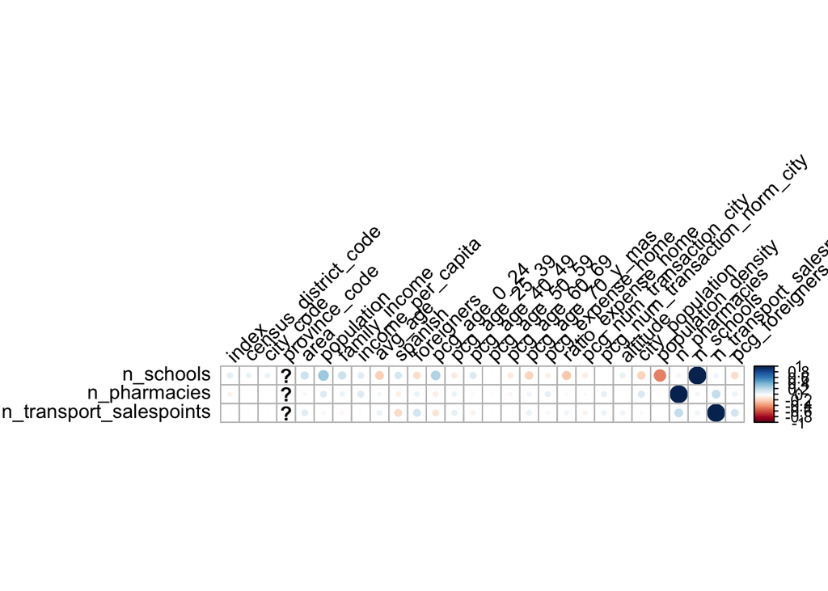

```r
#then discard the variables that arent correlated, at least all the ethnicity/nationality variables seem to be irrelevant because of the low values shown in corr
df1 <- df %>%
  dplyr::select(-c(12:45)) #ethnicities away

#heat map again
numeric_columns <- sapply(df1, is.numeric)
cor_matrix <- cor(df1[target_columns], df1[ , numeric_columns], use = "complete.obs")
corr <- corrplot(cor_matrix, method = "circle", tl.col = "black", tl.srt = 45)
```

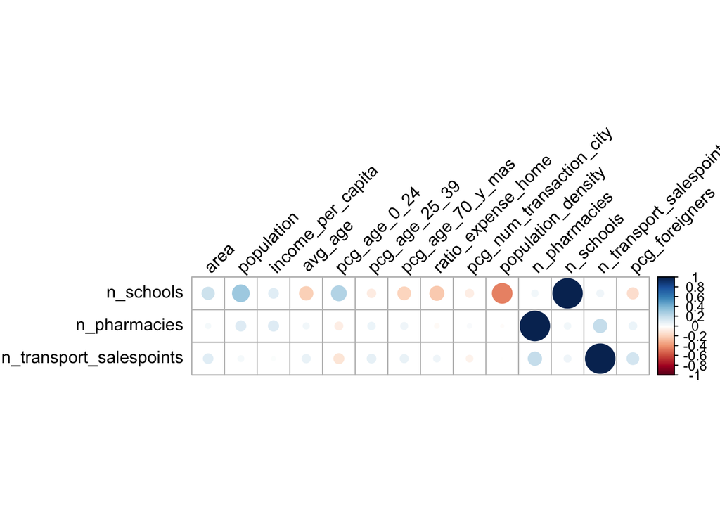

```r
#discard more irrelevant variables
df2 <- df1 %>%
  dplyr::select(-c(1:4, "pcg_age_40_49", "pcg_age_50_59", "pcg_age_60_69", "pcg_num_transaction_norm_city", "altitude", "city_population", "spanish", "foreigners", "family_income", "pcg_expense_home"))


#heat map again
numeric_columns <- sapply(df2, is.numeric)
cor_matrix <- cor(df2[target_columns], df2[ , numeric_columns], use = "complete.obs")
corr <- corrplot(cor_matrix, method = "circle", tl.col = "black", tl.srt = 45)
```

```r
#find top few correlated variables for each target variable
cor_matrix
```

```
##                               area population income_per_capita     avg_age
## n_schools               0.17082068 0.31947639        0.10836214 -0.20394395
## n_pharmacies            0.03092677 0.11592326        0.11828534  0.04185491
## n_transport_salespoints 0.10516170 0.03941877        0.01543601  0.07780379
##                         pcg_age_0_24 pcg_age_25_39 pcg_age_70_y_mas
## n_schools                 0.25223293   -0.08181945      -0.18678550
## n_pharmacies             -0.07169534    0.06288279       0.05486404
## n_transport_salespoints  -0.11366638    0.08535024       0.07369122
##                         ratio_expense_home pcg_num_transaction_city
## n_schools                      -0.22578850              -0.07676761
## n_pharmacies                   -0.02534993               0.02261234
## n_transport_salespoints         0.05006849              -0.05099902
##                         population_density n_pharmacies  n_schools
## n_schools                     -0.442516349   0.04785265 1.00000000
## n_pharmacies                  -0.010547263   1.00000000 0.04785265
## n_transport_salespoints       -0.002833247   0.20319966 0.05461251
##                         n_transport_salespoints pcg_foreigners
## n_schools                            0.05461251    -0.14201059
## n_pharmacies                         0.20319966     0.06855323
## n_transport_salespoints              1.00000000     0.15730223
```

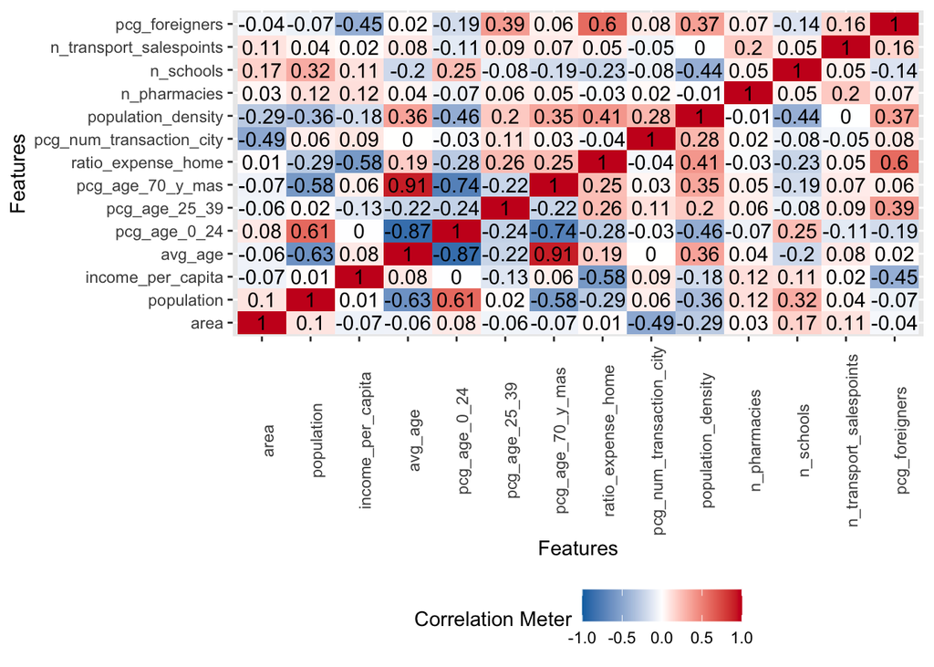

```r
#to check for general colinearity between variables
DataExplorer::plot_correlation(df2)
```

Here I filtered out ethnicity variables, and other variables that had little to no relevance on all of the target variables. It seems that one of the target variables (transport salespoints) isn’t related much with any of the any variables, so I have to be more sensitive when choosing variables related to that. It seems the most correlated variables are correlated most heavily with the amount of schools.

I also chose to remove some variables that give off the same information. For example there are many measures for population, so I chose to remove the for example the city_population variable and keep population and population_density (which also provides similar information). So lastly we should only have relevant variables for the target variables that are not very similar to other variables included.

Lastly I manually go through the last independent variables that are left to see what the top correlated variables are for each target variable.

For the amount of schools the variables that give the greatest values in magnitude are: population_density (-0.44), population (0.32), pcg_age_0_24 (0.25), ratio_expense_home (-0.22)

For the amount of pharmacies the variables that give the greatest values in magnitude are: n_transport_salespoints (0.2), income_per_capita (0.11), population (0.11)

For the amount of transport salespoints the variables that give the greatest values in magnitude are: n_pharmacies (0.2), pcg_foreigners (0.16), pcg_age_0_24 (0.11).

In the end I check the big correlation heat map to check for colinearity between variables, and note that for example average age and percentage of young people (0-25) are highly correlated and including both of them as an explanatory variable could be irrelevant as it provides a lot of the same information.

# Feature engineering and selection

Here I set out to see if there are any meaningful transformations that can be made to the data. Just to be sure I’ve exhausted the options, I squared and cubed all the variables left and also included some interaction terms.

```r
knitr::opts_chunk$set(echo = TRUE)
df10 <- df2 |>
  mutate(
    population2 = population^2,
    population3 = population^3,
    income_per_capita2 = income_per_capita^2,
    income_per_capita3 = income_per_capita^3,
    avg_age2 = avg_age^2,
    avg_age3 = avg_age^3,
    pcg_age_0_24_2 = pcg_age_0_24^2,
    pcg_age_0_24_3 = pcg_age_0_24^3,
    pcg_age_25_39_2 = pcg_age_25_39^2,
    pcg_age_25_39_3 = pcg_age_25_39^3,
    pcg_age_70_y_mas_2 = pcg_age_70_y_mas^2,
    pcg_age_70_y_mas_3 = pcg_age_70_y_mas^3,
    population_density2 = population_density^2,
    population_density3 = population_density^3,
    ratio_expense_home2 = ratio_expense_home^2,
    ratio_expense_home3 = ratio_expense_home^3,
    pcg_num_transaction_city2 = pcg_num_transaction_city^2,
    pcg_num_transaction_city3 = pcg_num_transaction_city^3,
    n_transport_salespoints_2 = n_transport_salespoints^2,
    n_transport_salespoints_3 = n_transport_salespoints^3,
    n_schools_2 = n_schools^2,
    n_schools_3 = n_schools^3,
    n_pharmacies_2 = n_pharmacies^2,
    n_pharmacies_3 = n_pharmacies^3,
    pcg_foreigners2 = pcg_foreigners^2,
    pcg_foreigners3 = pcg_foreigners^3,
    pop_popdens = population*population_density,
    pharm_trans = n_pharmacies*n_transport_salespoints,
    trans_school = n_transport_salespoints*n_schools,
    school_pharm = n_schools*n_pharmacies,
    #log_pcg_foreigners = log(pcg_foreigners) #non-normally distributed so lets try this
    )


df_scaled <- as.data.frame(scale(df10))
```

```r
knitr::opts_chunk$set(echo = TRUE)
#target variable n_schools
X <- df_scaled |>
  dplyr::select(-n_schools_2, -n_schools_3)

Y<-df_scaled %>%
  dplyr::select(n_schools)

modellm<-lm(n_schools ~ .,data=X)
round(coefficients(modellm),3)
```

```
##               (Intercept)                      area                population
##                     0.000                    -0.016                     0.218
##         income_per_capita                   avg_age              pcg_age_0_24
##                     0.283                    -0.843                    -0.382
##             pcg_age_25_39          pcg_age_70_y_mas        ratio_expense_home
##                     0.092                     0.416                     0.142
##  pcg_num_transaction_city        population_density              n_pharmacies
##                     0.419                    -0.658                    -0.255
##   n_transport_salespoints            pcg_foreigners               population2
##                    -0.050                     0.028                     0.069
##               population3        income_per_capita2        income_per_capita3
##                    -0.198                    -0.590                     0.309
##                  avg_age2                  avg_age3            pcg_age_0_24_2
##                     2.431                    -1.556                     0.712
##            pcg_age_0_24_3           pcg_age_25_39_2           pcg_age_25_39_3
##                    -0.276                    -0.043                     0.007
##        pcg_age_70_y_mas_2        pcg_age_70_y_mas_3       population_density2
##                    -0.849                     0.571                     0.633
##       population_density3       ratio_expense_home2       ratio_expense_home3
##                    -0.221                    -0.272                     0.120
## pcg_num_transaction_city2 pcg_num_transaction_city3 n_transport_salespoints_2
##                    -1.155                     0.808                     0.004
## n_transport_salespoints_3            n_pharmacies_2            n_pharmacies_3
##                    -0.016                     0.189                    -0.233
##           pcg_foreigners2           pcg_foreigners3               pop_popdens
##                    -0.079                     0.052                    -0.044
##               pharm_trans              trans_school              school_pharm
##                    -0.038                     0.192                     0.611
```

```r
summary(modellm)
```

```
##
## Call:
## lm(formula = n_schools ~ ., data = X)
##
## Residuals:
##     Min      1Q  Median      3Q     Max
## -6.2623 -0.3371 -0.0803  0.2282  5.9092
##
## Coefficients:
##                             Estimate Std. Error t value Pr(>|t|)
## (Intercept)                4.675e-17  9.417e-03   0.000 1.000000
## area                      -1.609e-02  1.221e-02  -1.318 0.187578
## population                 2.182e-01  1.648e-01   1.324 0.185464
## income_per_capita          2.827e-01  2.793e-01   1.012 0.311475
## avg_age                   -8.428e-01  1.641e+00  -0.514 0.607568
## pcg_age_0_24              -3.822e-01  3.173e-01  -1.205 0.228418
## pcg_age_25_39              9.199e-02  1.588e-01   0.579 0.562317
## pcg_age_70_y_mas           4.160e-01  1.092e-01   3.809 0.000142 ***
## ratio_expense_home         1.416e-01  1.725e-01   0.820 0.412014
## pcg_num_transaction_city   4.194e-01  1.660e-01   2.526 0.011582 *
## population_density        -6.577e-01  8.240e-02  -7.982 1.83e-15 ***
## n_pharmacies              -2.546e-01  3.759e-02  -6.772 1.43e-11 ***
## n_transport_salespoints   -4.974e-02  4.774e-02  -1.042 0.297597
## pcg_foreigners             2.823e-02  8.730e-02   0.323 0.746425
## population2                6.886e-02  3.175e-01   0.217 0.828329
## population3               -1.984e-01  1.686e-01  -1.176 0.239524
## income_per_capita2        -5.902e-01  5.492e-01  -1.075 0.282607
## income_per_capita3         3.086e-01  2.869e-01   1.076 0.282088
## avg_age2                   2.431e+00  3.340e+00   0.728 0.466629
## avg_age3                  -1.556e+00  1.721e+00  -0.904 0.366053
## pcg_age_0_24_2             7.124e-01  6.392e-01   1.115 0.265099
## pcg_age_0_24_3            -2.756e-01  3.300e-01  -0.835 0.403749
## pcg_age_25_39_2           -4.276e-02  2.941e-01  -0.145 0.884434
## pcg_age_25_39_3            7.065e-03  1.513e-01   0.047 0.962764
## pcg_age_70_y_mas_2        -8.493e-01  1.653e-01  -5.139 2.88e-07 ***
## pcg_age_70_y_mas_3         5.709e-01  8.877e-02   6.432 1.40e-10 ***
## population_density2        6.326e-01  1.253e-01   5.048 4.65e-07 ***
## population_density3       -2.213e-01  7.167e-02  -3.088 0.002030 **
## ratio_expense_home2       -2.718e-01  3.292e-01  -0.826 0.409121
## ratio_expense_home3        1.199e-01  1.698e-01   0.706 0.480033
## pcg_num_transaction_city2 -1.155e+00  4.365e-01  -2.647 0.008148 **
## pcg_num_transaction_city3  8.079e-01  2.816e-01   2.869 0.004132 **
## n_transport_salespoints_2  3.593e-03  9.491e-02   0.038 0.969803
## n_transport_salespoints_3 -1.633e-02  5.800e-02  -0.282 0.778252
## n_pharmacies_2             1.891e-01  7.847e-02   2.410 0.016009 *
## n_pharmacies_3            -2.334e-01  5.143e-02  -4.539 5.81e-06 ***
## pcg_foreigners2           -7.879e-02  1.652e-01  -0.477 0.633378
## pcg_foreigners3            5.168e-02  9.157e-02   0.564 0.572518
## pop_popdens               -4.405e-02  3.528e-02  -1.249 0.211913
## pharm_trans               -3.836e-02  1.688e-02  -2.273 0.023063 *
## trans_school               1.925e-01  1.304e-02  14.755  < 2e-16 ***
## school_pharm               6.106e-01  1.325e-02  46.098  < 2e-16 ***
## ---
## Signif. codes:  0 '***' 0.001 '**' 0.01 '*' 0.05 '.' 0.1 ' ' 1
##
## Residual standard error: 0.6256 on 4372 degrees of freedom
## Multiple R-squared:  0.6122, Adjusted R-squared:  0.6086
## F-statistic: 168.4 on 41 and 4372 DF,  p-value: < 2.2e-16
```

Here I tried many transformations to be done on all the remaining variables, squaring and cubing all of the variables just to see what would happen. Testing it using a linear regression model to see how they end up being in the model and which ones end up being significant. Many variables coefficients show as very close to 0 showing that they don’t seem to be very relevant for this assignment in examining n_schools. Next up lets try a different model, lasso regression and do this for all the different target variables to come to a final decision about which variables to keep and which to get rid of before taking them to the regression models.

I decided to keep different sets of variables for each target variable, so I create new data bases including the selected variables to be used later in the training and testing of the different regression models.

## Lasso regression: n_schools

```r
knitr::opts_chunk$set(echo = TRUE)
#target variable: n_schools
X<-df_scaled %>%
  dplyr::select(-c(n_schools, n_schools_2, n_schools_3))
Y<-df_scaled %>%
  dplyr::select(n_schools)
grid = 10^seq(10, -2, length = 100)

#lasso regression (alpha=1, search for best lambda) and do CV
model2<-cv.glmnet(x=as.matrix(na.omit(X)), y=Y[,1], lambda=grid, alpha=1)

#example to extract predictions
predict(model2, newx=as.matrix(X)[1:10,], s="lambda.min")
```

```
##       lambda.min
##  [1,] -0.2556463
##  [2,] -0.8972182
##  [3,] -0.6346977
##  [4,] -0.5802258
##  [5,] -0.1668151
##  [6,] -0.1079440
##  [7,]  0.6391273
##  [8,]  0.1026289
##  [9,] -0.2360605
## [10,] -0.5942183
```

```r
#example to extract coefficients
as.data.frame(as.matrix(predict(model2, type="coefficients", s="lambda.min"))) %>%
  mutate(across(c(lambda.min), round, 2))
```

```
##                           lambda.min
## (Intercept)                     0.00
## area                            0.00
## population                      0.09
## income_per_capita               0.00
## avg_age                         0.00
## pcg_age_0_24                    0.00
## pcg_age_25_39                   0.01
## pcg_age_70_y_mas                0.00
## ratio_expense_home              0.00
## pcg_num_transaction_city        0.04
## population_density             -0.31
## n_pharmacies                   -0.17
## n_transport_salespoints        -0.03
## pcg_foreigners                  0.01
## population2                     0.00
## population3                    -0.02
## income_per_capita2              0.00
## income_per_capita3              0.00
## avg_age2                        0.00
## avg_age3                        0.00
## pcg_age_0_24_2                  0.00
## pcg_age_0_24_3                  0.00
## pcg_age_25_39_2                 0.00
## pcg_age_25_39_3                 0.00
## pcg_age_70_y_mas_2              0.00
## pcg_age_70_y_mas_3              0.04
## population_density2             0.00
## population_density3             0.08
## ratio_expense_home2            -0.01
## ratio_expense_home3             0.00
## pcg_num_transaction_city2       0.00
## pcg_num_transaction_city3       0.00
## n_transport_salespoints_2      -0.01
## n_transport_salespoints_3       0.00
## n_pharmacies_2                  0.00
## n_pharmacies_3                 -0.10
## pcg_foreigners2                 0.00
## pcg_foreigners3                 0.00
## pop_popdens                     0.00
## pharm_trans                    -0.03
## trans_school                    0.18
## school_pharm                    0.60
```

```r
df_n_school <- df10 |> #select all non-0 lambda.min (I didn't include <0.02 because their effect would be so small, except in the case of the percentage of ages, because I feel like those have to be relevant!)
  dplyr::select(c("n_schools", "population","pcg_age_0_24", "pcg_age_25_39", "population_density", "pcg_num_transaction_city", "n_transport_salespoints", "pcg_age_70_y_mas_3"))
```

## Lasso regression: n_pharmacies

```r
knitr::opts_chunk$set(echo = TRUE)
#target variable n_pharmacies
X<-df_scaled %>%
  dplyr::select(-c(n_pharmacies, n_pharmacies_2, n_pharmacies_3))
Y<-df_scaled %>%
  dplyr::select(n_pharmacies)
grid = 10^seq(10, -2, length = 100)

#lasso regression (alpha=1, search for best lambda) and do CV
model2<-cv.glmnet(x=as.matrix(X), y=Y[,1], lambda=grid, alpha=1)

#example to extract predictions
predict(model2, newx=as.matrix(X)[1:10,], s="lambda.min")
```

```
##         lambda.min
##  [1,] -0.277941736
##  [2,] -0.009559879
##  [3,]  0.049421037
##  [4,] -0.346897178
##  [5,] -0.231918198
##  [6,] -0.362915320
##  [7,] -1.184175158
##  [8,] -0.223831680
##  [9,]  0.042799331
## [10,] -0.378914796
```

```r
#example to extract coefficients
as.data.frame(as.matrix(predict(model2, type="coefficients", s="lambda.min"))) %>%
  mutate(across(c(lambda.min), round, 2))
```

```
##                           lambda.min
## (Intercept)                     0.00
## area                            0.00
## population                      0.07
## income_per_capita               0.07
## avg_age                         0.00
## pcg_age_0_24                    0.00
## pcg_age_25_39                   0.01
## pcg_age_70_y_mas                0.04
## ratio_expense_home              0.00
## pcg_num_transaction_city        0.00
## population_density              0.00
## n_schools                      -0.23
## n_transport_salespoints        -0.03
## pcg_foreigners                  0.05
## population2                     0.00
## population3                     0.00
## income_per_capita2              0.00
## income_per_capita3              0.00
## avg_age2                        0.00
## avg_age3                        0.00
## pcg_age_0_24_2                 -0.05
## pcg_age_0_24_3                  0.00
## pcg_age_25_39_2                 0.00
## pcg_age_25_39_3                 0.00
## pcg_age_70_y_mas_2              0.00
## pcg_age_70_y_mas_3              0.01
## population_density2            -0.03
## population_density3            -0.05
## ratio_expense_home2             0.00
## ratio_expense_home3             0.00
## pcg_num_transaction_city2       0.00
## pcg_num_transaction_city3       0.00
## n_transport_salespoints_2      -0.13
## n_transport_salespoints_3       0.00
## n_schools_2                     0.00
## n_schools_3                    -0.07
## pcg_foreigners2                 0.00
## pcg_foreigners3                 0.00
## pop_popdens                     0.08
## pharm_trans                     0.46
## trans_school                   -0.11
## school_pharm                    0.58
```

```r
df_n_pharmacies <- df10 |>  #select all non-0 lambda.min (I didn't include <0.02 because their effect would be so small)
  dplyr::select(c("n_pharmacies", "population", "income_per_capita", "pcg_age_25_39", "pcg_age_70_y_mas", "n_transport_salespoints_2", "n_schools", "pcg_foreigners", "population_density2", "pharm_trans", "pop_popdens" ))
```

## Lasso regression: n_transport_salespoints

```r
knitr::opts_chunk$set(echo = TRUE)
#target variable n_transport_salespoints
X<-df_scaled %>%
  dplyr::select(-c(n_transport_salespoints, n_transport_salespoints_2, n_transport_salespoints_3))
Y<-df_scaled %>%
  dplyr::select(n_transport_salespoints)
grid = 10^seq(10, -2, length = 100)

#lasso regression (alpha=1, search for best lambda) and do CV
model2<-cv.glmnet(x=as.matrix(X), y=Y[,1], lambda=grid, alpha=1)

#example to extract predictions
predict(model2, newx=as.matrix(X)[1:10,], s="lambda.min")
```

```
##        lambda.min
##  [1,] -0.14901291
##  [2,] -0.46027701
##  [3,] -0.09227923
##  [4,] -0.11678001
##  [5,] -0.25527138
##  [6,] -0.23732875
##  [7,]  0.47169095
##  [8,] -0.35255673
##  [9,] -0.33826092
## [10,] -0.14854018
```

```r
#example to extract coefficients
as.data.frame(as.matrix(predict(model2, type="coefficients", s="lambda.min"))) %>%
  mutate(across(c(lambda.min), round, 2))
```

```
##                           lambda.min
## (Intercept)                     0.00
## area                            0.02
## population                      0.00
## income_per_capita               0.02
## avg_age                         0.00
## pcg_age_0_24                   -0.03
## pcg_age_25_39                   0.00
## pcg_age_70_y_mas                0.00
## ratio_expense_home              0.00
## pcg_num_transaction_city        0.00
## population_density              0.00
## n_pharmacies                    0.00
## n_schools                       0.00
## pcg_foreigners                  0.06
## population2                     0.00
## population3                     0.00
## income_per_capita2              0.00
## income_per_capita3              0.00
## avg_age2                        0.00
## avg_age3                        0.00
## pcg_age_0_24_2                  0.00
## pcg_age_0_24_3                  0.00
## pcg_age_25_39_2                 0.00
## pcg_age_25_39_3                 0.00
## pcg_age_70_y_mas_2              0.00
## pcg_age_70_y_mas_3              0.01
## population_density2             0.00
## population_density3             0.00
## ratio_expense_home2             0.00
## ratio_expense_home3             0.00
## pcg_num_transaction_city2       0.00
## pcg_num_transaction_city3       0.00
## n_schools_2                    -0.05
## n_schools_3                     0.00
## n_pharmacies_2                 -0.13
## n_pharmacies_3                 -0.01
## pcg_foreigners2                 0.00
## pcg_foreigners3                 0.00
## pop_popdens                     0.01
## pharm_trans                     0.67
## trans_school                    0.30
## school_pharm                   -0.07
```

```r
df_n_transport_salespoints <- df10 |> #select all non-0 lambda.min (I didn't include <0.02 because their effect would be so small)
  dplyr::select(c("n_transport_salespoints", "area", "population", "income_per_capita", "pcg_age_0_24", "pcg_age_25_39", "pcg_age_70_y_mas", "pcg_num_transaction_city", "n_pharmacies", "n_schools", "pcg_foreigners", "pharm_trans"))
```

# Regression models

When starting with the process of finding the best fitting model for each target variable, I wanted to ensure we don’t find the model ‘by chance’, so I employed the splitting of the dataset into the ‘training’ data and ‘testing’ data. Then when doing my training and trying to find the best fitting model, I use the training data and ensure my results are accurate by testing it with the testing data set. In this entire section, my hypothesis here is using the set of variables that I have pre-selected from the results of the lasso regression, which model is able to most accurately represent the data? And to then choose the best model and evaluate it using the test data. After finding the best model of those tested, I generate a score and my hypothesis moves to be, that I am able to model and predict whether there are enough facilities for each target variable.

```r
knitr::opts_chunk$set(echo = TRUE)
#split all data sets into train and test data set

#df_n_school: split train and test datasets
training.samples_s <- df_n_school$n_schools %>%
  createDataPartition(p = 0.8, list = FALSE)
train.data_schools  <- df_n_school[training.samples_s, ]
test.data_schools <- df_n_school[-training.samples_s, ]

#df_n_pharmacies: split train and test datasets
training.samples_p <- df_n_pharmacies$n_pharmacies %>%
  createDataPartition(p = 0.8, list = FALSE)
train.data_pharmacies  <- df_n_pharmacies[training.samples_p, ]
test.data_pharmacies <- df_n_pharmacies[-training.samples_p, ]

#df_n_transportation: split train and test datasets
training.samples_t <- df_n_transport_salespoints$n_transport_salespoints%>%
  createDataPartition(p = 0.8, list = FALSE)
train.data_transportation  <- df_n_transport_salespoints[training.samples_t, ]
test.data_transportation <- df_n_transport_salespoints[-training.samples_t, ]
```

## Target variable 1: n_schools

```r
knitr::opts_chunk$set(echo = TRUE)
#Target variable 1: n_schools, train data

# train linear model
lm_model <- lm(n_schools ~ population + pcg_age_0_24 + pcg_age_25_39 + pcg_num_transaction_city  + n_transport_salespoints   + pcg_age_70_y_mas_3  , data = train.data_schools)
summary(lm_model)
```

```
##
## Call:
## lm(formula = n_schools ~ population + pcg_age_0_24 + pcg_age_25_39 +
##     pcg_num_transaction_city + n_transport_salespoints + pcg_age_70_y_mas_3,
##     data = train.data_schools)
##
## Residuals:
##     Min      1Q  Median      3Q     Max
## -2.9058 -0.7333 -0.3928  0.4543 11.0057
##
## Coefficients:
##                            Estimate Std. Error t value Pr(>|t|)
## (Intercept)               1.501e+00  3.583e-01   4.190 2.86e-05 ***
## population                7.106e-04  4.952e-05  14.352  < 2e-16 ***
## pcg_age_0_24              1.533e+00  5.249e-01   2.920  0.00352 **
## pcg_age_25_39            -1.484e+00  4.563e-01  -3.252  0.00116 **
## pcg_num_transaction_city -1.784e-02  3.267e-03  -5.460 5.08e-08 ***
## n_transport_salespoints   1.318e-01  4.198e-02   3.140  0.00171 **
## pcg_age_70_y_mas_3        2.590e+00  3.997e+00   0.648  0.51693
## ---
## Signif. codes:  0 '***' 0.001 '**' 0.01 '*' 0.05 '.' 0.1 ' ' 1
##
## Residual standard error: 1.276 on 3525 degrees of freedom
## Multiple R-squared:  0.1275, Adjusted R-squared:  0.126
## F-statistic: 85.84 on 6 and 3525 DF,  p-value: < 2.2e-16
```

```r
# Train a negative binomial model
negbin_model <- glm.nb(n_schools ~ population + pcg_age_0_24 + pcg_age_25_39 + pcg_num_transaction_city  + n_transport_salespoints   + pcg_age_70_y_mas_3, data = train.data_schools)

# Summary of the negative binomial model
summary(negbin_model)
```

```
##
## Call:
## glm.nb(formula = n_schools ~ population + pcg_age_0_24 + pcg_age_25_39 +
##     pcg_num_transaction_city + n_transport_salespoints + pcg_age_70_y_mas_3,
##     data = train.data_schools, init.theta = 1.432627827, link = log)
##
## Coefficients:
##                            Estimate Std. Error z value Pr(>|z|)
## (Intercept)               3.286e-01  3.574e-01   0.919 0.357839
## population                6.721e-04  4.983e-05  13.487  < 2e-16 ***
## pcg_age_0_24              1.696e+00  5.483e-01   3.092 0.001986 **
## pcg_age_25_39            -1.661e+00  4.795e-01  -3.463 0.000534 ***
## pcg_num_transaction_city -1.660e-02  3.218e-03  -5.160 2.47e-07 ***
## n_transport_salespoints   1.031e-01  4.394e-02   2.347 0.018948 *
## pcg_age_70_y_mas_3        5.967e-01  4.663e+00   0.128 0.898162
## ---
## Signif. codes:  0 '***' 0.001 '**' 0.01 '*' 0.05 '.' 0.1 ' ' 1
##
## (Dispersion parameter for Negative Binomial(1.4326) family taken to be 1)
##
##     Null deviance: 3925.4  on 3531  degrees of freedom
## Residual deviance: 3433.1  on 3525  degrees of freedom
## AIC: 8939.5
##
## Number of Fisher Scoring iterations: 1
##
##
##               Theta:  1.433
##           Std. Err.:  0.105
##
##  2 x log-likelihood:  -8923.460
```

```r
# Normal Poisson regression model
poisson_model <- glm(n_schools ~ population + pcg_age_0_24 + pcg_age_25_39 + pcg_num_transaction_city + n_transport_salespoints + pcg_age_70_y_mas_3, family = poisson(link = "log"), data = train.data_schools)

# Summary of the Poisson regression model
summary(poisson_model)
```

```
##
## Call:
## glm(formula = n_schools ~ population + pcg_age_0_24 + pcg_age_25_39 +
##     pcg_num_transaction_city + n_transport_salespoints + pcg_age_70_y_mas_3,
##     family = poisson(link = "log"), data = train.data_schools)
##
## Coefficients:
##                            Estimate Std. Error z value Pr(>|z|)
## (Intercept)               4.514e-01  2.574e-01   1.754 0.079472 .
## population                6.265e-04  3.577e-05  17.513  < 2e-16 ***
## pcg_age_0_24              1.465e+00  4.096e-01   3.576 0.000349 ***
## pcg_age_25_39            -1.686e+00  3.596e-01  -4.690 2.73e-06 ***
## pcg_num_transaction_city -1.644e-02  2.300e-03  -7.146 8.92e-13 ***
## n_transport_salespoints   1.246e-01  3.201e-02   3.894 9.86e-05 ***
## pcg_age_70_y_mas_3       -1.242e+00  3.795e+00  -0.327 0.743403
## ---
## Signif. codes:  0 '***' 0.001 '**' 0.01 '*' 0.05 '.' 0.1 ' ' 1
##
## (Dispersion parameter for poisson family taken to be 1)
##
##     Null deviance: 6149.7  on 3531  degrees of freedom
## Residual deviance: 5337.3  on 3525  degrees of freedom
## AIC: 9416.8
##
## Number of Fisher Scoring iterations: 6
```

```r
# Quasi Poisson regression model
quasi_poisson_model <- glm(n_schools ~ population + pcg_age_0_24 + pcg_age_25_39 + pcg_num_transaction_city  + n_transport_salespoints   + pcg_age_70_y_mas_3, family = quasipoisson(link = "log"), data = train.data_schools)

# Summary of the Quasi-Poisson regression model
summary(quasi_poisson_model)
```

```
##
## Call:
## glm(formula = n_schools ~ population + pcg_age_0_24 + pcg_age_25_39 +
##     pcg_num_transaction_city + n_transport_salespoints + pcg_age_70_y_mas_3,
##     family = quasipoisson(link = "log"), data = train.data_schools)
##
## Coefficients:
##                            Estimate Std. Error t value Pr(>|t|)
## (Intercept)               4.514e-01  3.421e-01   1.319 0.187154
## population                6.265e-04  4.755e-05  13.175  < 2e-16 ***
## pcg_age_0_24              1.465e+00  5.444e-01   2.690 0.007179 **
## pcg_age_25_39            -1.686e+00  4.780e-01  -3.528 0.000424 ***
## pcg_num_transaction_city -1.644e-02  3.058e-03  -5.376 8.12e-08 ***
## n_transport_salespoints   1.246e-01  4.255e-02   2.929 0.003419 **
## pcg_age_70_y_mas_3       -1.242e+00  5.045e+00  -0.246 0.805498
## ---
## Signif. codes:  0 '***' 0.001 '**' 0.01 '*' 0.05 '.' 0.1 ' ' 1
##
## (Dispersion parameter for quasipoisson family taken to be 1.767059)
##
##     Null deviance: 6149.7  on 3531  degrees of freedom
## Residual deviance: 5337.3  on 3525  degrees of freedom
## AIC: NA
##
## Number of Fisher Scoring iterations: 6
```

```r
# Compare models using AIC
aic_results <- c(AIC(lm_model), AIC(negbin_model), AIC(poisson_model), AIC(quasi_poisson_model))

# Compare models using BIC
bic_results <- c(BIC(lm_model), BIC(negbin_model), BIC(poisson_model), BIC(quasi_poisson_model))

# Show results
list(AIC = aic_results, BIC = bic_results)
```

```
## $AIC
## [1] 11753.867  8939.460  9416.838        NA
##
## $BIC
## [1] 11803.224  8988.817  9460.026        NA
```

Then I tried a few other models that might work better for this. I tried the negative binomial model, and while it seemed to perform better than the linear model, it had the lowest AIC of them all, and a Fisher scoring of only 1. I tried out the 2 different poisson models, normal poisson and quasi poisson, they produced quite similar results, however the quasi poisson wasn’t able to produce a AIC which makes it difficult to compare as it is an important metric. I also noted that the Fisher scoring in both poissons is much higher than the negative binomial model.

## Model validation

```r
knitr::opts_chunk$set(echo = TRUE)
#relationship of variance and mean
var(df_n_school$n_schools)/mean(df_n_school$n_schools)
```

```
## [1] 1.980051
```

```r
#final test on the negative binomial model
negbin_model_test_data <- glm.nb(n_schools ~ population + pcg_age_0_24 + pcg_age_25_39 + pcg_num_transaction_city  + n_transport_salespoints   + pcg_age_70_y_mas_3, data = test.data_schools)

# Summary of the negative binomial model
summary(negbin_model)
```

```
##
## Call:
## glm.nb(formula = n_schools ~ population + pcg_age_0_24 + pcg_age_25_39 +
##     pcg_num_transaction_city + n_transport_salespoints + pcg_age_70_y_mas_3,
##     data = train.data_schools, init.theta = 1.432627827, link = log)
##
## Coefficients:
##                            Estimate Std. Error z value Pr(>|z|)
## (Intercept)               3.286e-01  3.574e-01   0.919 0.357839
## population                6.721e-04  4.983e-05  13.487  < 2e-16 ***
## pcg_age_0_24              1.696e+00  5.483e-01   3.092 0.001986 **
## pcg_age_25_39            -1.661e+00  4.795e-01  -3.463 0.000534 ***
## pcg_num_transaction_city -1.660e-02  3.218e-03  -5.160 2.47e-07 ***
## n_transport_salespoints   1.031e-01  4.394e-02   2.347 0.018948 *
## pcg_age_70_y_mas_3        5.967e-01  4.663e+00   0.128 0.898162
## ---
## Signif. codes:  0 '***' 0.001 '**' 0.01 '*' 0.05 '.' 0.1 ' ' 1
##
## (Dispersion parameter for Negative Binomial(1.4326) family taken to be 1)
##
##     Null deviance: 3925.4  on 3531  degrees of freedom
## Residual deviance: 3433.1  on 3525  degrees of freedom
## AIC: 8939.5
##
## Number of Fisher Scoring iterations: 1
##
##
##               Theta:  1.433
##           Std. Err.:  0.105
##
##  2 x log-likelihood:  -8923.460
```

```r
#save plot for later
# Predicted values using negative binomial model
negbin_predictions <- predict(negbin_model_test_data, type = "response")
```

## Score generation

```r
knitr::opts_chunk$set(echo = TRUE)

df_n_school_2 <- df_n_school |>
  mutate(predictions = predict(negbin_model,
                                   newdata = df_n_school,
                                   type = "response")) |>
  mutate(score = case_when(
    predictions - n_schools > 0.5 ~ 1,
    .default = 0
    )
  )

logistic_model <- glm(score ~ population + pcg_age_0_24 + pcg_age_25_39 + pcg_num_transaction_city + n_transport_salespoints + pcg_age_70_y_mas_3,
                      data = df_n_school_2,
                      family = binomial)

# Display a summary of the model
summary(logistic_model)
```

```
##
## Call:
## glm(formula = score ~ population + pcg_age_0_24 + pcg_age_25_39 +
##     pcg_num_transaction_city + n_transport_salespoints + pcg_age_70_y_mas_3,
##     family = binomial, data = df_n_school_2)
##
## Coefficients:
##                            Estimate Std. Error z value Pr(>|z|)
## (Intercept)              -1.779e-01  5.099e-01  -0.349  0.72722
## population                2.282e-04  7.023e-05   3.249  0.00116 **
## pcg_age_0_24             -2.178e-01  7.273e-01  -0.299  0.76457
## pcg_age_25_39            -2.900e+00  6.624e-01  -4.378  1.2e-05 ***
## pcg_num_transaction_city  3.775e-03  4.713e-03   0.801  0.42309
## n_transport_salespoints   1.139e-01  5.995e-02   1.900  0.05748 .
## pcg_age_70_y_mas_3       -4.613e+00  5.070e+00  -0.910  0.36290
## ---
## Signif. codes:  0 '***' 0.001 '**' 0.01 '*' 0.05 '.' 0.1 ' ' 1
##
## (Dispersion parameter for binomial family taken to be 1)
##
##     Null deviance: 6106.9  on 4413  degrees of freedom
## Residual deviance: 6061.8  on 4407  degrees of freedom
## AIC: 6075.8
##
## Number of Fisher Scoring iterations: 4
```

```r
#Coefficients for interpretation
round(exp(coef(logistic_model)),2)
```

```
##              (Intercept)               population             pcg_age_0_24
##                     0.84                     1.00                     0.80
##            pcg_age_25_39 pcg_num_transaction_city  n_transport_salespoints
##                     0.06                     1.00                     1.12
##       pcg_age_70_y_mas_3
##                     0.01
```

```r
# Make predictions
probabilities <- logistic_model %>% predict(df_n_school_2, type = "response")
predicted.classes <- ifelse(probabilities > 0.5, "1", "0")
# Model accuracy
mean(predicted.classes == df_n_school_2$score)
```

```
## [1] 0.5067966
```

```r
#confusion matrix
confusionMatrix(as.factor(df_n_school_2$score), as.factor(predicted.classes))
```

```
## Confusion Matrix and Statistics
##
##           Reference
## Prediction    0    1
##          0 1686  637
##          1 1540  551
##
##                Accuracy : 0.5068
##                  95% CI : (0.4919, 0.5217)
##     No Information Rate : 0.7309
##     P-Value [Acc > NIR] : 1
##
##                   Kappa : -0.0109
##
##  Mcnemar's Test P-Value : <2e-16
##
##             Sensitivity : 0.5226
##             Specificity : 0.4638
##          Pos Pred Value : 0.7258
##          Neg Pred Value : 0.2635
##              Prevalence : 0.7309
##          Detection Rate : 0.3820
##    Detection Prevalence : 0.5263
##       Balanced Accuracy : 0.4932
##
##        'Positive' Class : 0
##
```

## Target variable 2: n_pharmacies

```r
knitr::opts_chunk$set(echo = TRUE)

#Target variable 1: n_pharmacies, train data

# train linear model
lm_model <- lm(n_pharmacies ~ population_density2 + pcg_age_25_39 + pcg_age_70_y_mas + pcg_foreigners + n_transport_salespoints_2 + pharm_trans , data = train.data_pharmacies)

# Summary of the linear model
summary(lm_model)
```

```
##
## Call:
## lm(formula = n_pharmacies ~ population_density2 + pcg_age_25_39 +
##     pcg_age_70_y_mas + pcg_foreigners + n_transport_salespoints_2 +
##     pharm_trans, data = train.data_pharmacies)
##
## Residuals:
##     Min      1Q  Median      3Q     Max
## -2.4201 -0.5489 -0.0363  0.4078  4.4165
##
## Coefficients:
##                             Estimate Std. Error t value Pr(>|t|)
## (Intercept)                3.695e-01  5.063e-02   7.299 3.58e-13 ***
## population_density2       -2.238e-11  8.137e-12  -2.751  0.00597 **
## pcg_age_25_39              4.661e-01  2.108e-01   2.211  0.02711 *
## pcg_age_70_y_mas           6.143e-01  1.574e-01   3.902 9.71e-05 ***
## pcg_foreigners             4.019e-03  1.530e-03   2.627  0.00866 **
## n_transport_salespoints_2 -2.543e-01  1.648e-02 -15.436  < 2e-16 ***
## pharm_trans                6.722e-01  2.064e-02  32.567  < 2e-16 ***
## ---
## Signif. codes:  0 '***' 0.001 '**' 0.01 '*' 0.05 '.' 0.1 ' ' 1
##
## Residual standard error: 0.6065 on 3525 degrees of freedom
## Multiple R-squared:  0.2653, Adjusted R-squared:  0.264
## F-statistic: 212.1 on 6 and 3525 DF,  p-value: < 2.2e-16
```

```r
# Train a negative binomial model
negbin_model <- glm.nb(n_pharmacies ~ population_density2 + pcg_age_25_39 + pcg_age_70_y_mas + pcg_foreigners + n_transport_salespoints_2 + pharm_trans, data = train.data_pharmacies)
```

[output not shown]

[output cut: 22 more lines]

[output not shown]

```r
# Summary of the negative binomial model
summary(negbin_model)
```

```
##
## Call:
## glm.nb(formula = n_pharmacies ~ population_density2 + pcg_age_25_39 +
##     pcg_age_70_y_mas + pcg_foreigners + n_transport_salespoints_2 +
##     pharm_trans, data = train.data_pharmacies, init.theta = 13169.54055,
##     link = log)
##
## Coefficients:
##                             Estimate Std. Error z value Pr(>|z|)
## (Intercept)               -8.407e-01  1.073e-01  -7.835 4.67e-15 ***
## population_density2       -3.974e-11  1.749e-11  -2.273 0.023053 *
## pcg_age_25_39              6.857e-01  4.354e-01   1.575 0.115279
## pcg_age_70_y_mas           1.145e+00  3.261e-01   3.510 0.000448 ***
## pcg_foreigners             7.318e-03  3.069e-03   2.385 0.017101 *
## n_transport_salespoints_2 -3.664e-01  4.268e-02  -8.584  < 2e-16 ***
## pharm_trans                5.658e-01  3.310e-02  17.090  < 2e-16 ***
## ---
## Signif. codes:  0 '***' 0.001 '**' 0.01 '*' 0.05 '.' 0.1 ' ' 1
##
## (Dispersion parameter for Negative Binomial(13169.54) family taken to be 1)
##
##     Null deviance: 3157.7  on 3531  degrees of freedom
## Residual deviance: 2732.1  on 3525  degrees of freedom
## AIC: 6835.4
##
## Number of Fisher Scoring iterations: 1
##
##
##               Theta:  13170
##           Std. Err.:  37067
## Warning while fitting theta: alternation limit reached
##
##  2 x log-likelihood:  -6819.376
```

```r
# Fit zero-inflated Poisson model
zip_model <- zeroinfl(n_pharmacies ~ population_density2 + pcg_age_25_39 + pcg_age_70_y_mas + pcg_foreigners + n_transport_salespoints_2 + pharm_trans | 1, dist = "poisson", data = train.data_pharmacies)

# Summary of the model
summary(zip_model)
```

```
##
## Call:
## zeroinfl(formula = n_pharmacies ~ population_density2 + pcg_age_25_39 +
##     pcg_age_70_y_mas + pcg_foreigners + n_transport_salespoints_2 + pharm_trans |
##     1, data = train.data_pharmacies, dist = "poisson")
##
## Pearson residuals:
##     Min      1Q  Median      3Q     Max
## -3.8999 -0.7624  0.2190  0.4880  5.6776
##
## Count model coefficients (poisson with log link):
##                             Estimate Std. Error z value Pr(>|z|)
## (Intercept)               -8.407e-01        NaN     NaN      NaN
## population_density2       -3.974e-11        NaN     NaN      NaN
## pcg_age_25_39              6.858e-01        NaN     NaN      NaN
## pcg_age_70_y_mas           1.145e+00        NaN     NaN      NaN
## pcg_foreigners             7.319e-03        NaN     NaN      NaN
## n_transport_salespoints_2 -3.664e-01        NaN     NaN      NaN
## pharm_trans                5.657e-01        NaN     NaN      NaN
##
## Zero-inflation model coefficients (binomial with logit link):
##             Estimate Std. Error z value Pr(>|z|)
## (Intercept)   -13.27        NaN     NaN      NaN
##
## Number of iterations in BFGS optimization: 53
## Log-likelihood: -3410 on 8 Df
```

```r
# Normal Poisson regression model
poisson_model <- glm(n_pharmacies ~ population_density2 + pcg_age_25_39 + pcg_age_70_y_mas + pcg_foreigners + n_transport_salespoints_2 + pharm_trans, family = poisson(link = "log"), data = train.data_pharmacies)

# Summary of the Poisson regression model
summary(poisson_model)
```

```
##
## Call:
## glm(formula = n_pharmacies ~ population_density2 + pcg_age_25_39 +
##     pcg_age_70_y_mas + pcg_foreigners + n_transport_salespoints_2 +
##     pharm_trans, family = poisson(link = "log"), data = train.data_pharmacies)
##
## Coefficients:
##                             Estimate Std. Error z value Pr(>|z|)
## (Intercept)               -8.407e-01  1.073e-01  -7.835 4.67e-15 ***
## population_density2       -3.975e-11  1.749e-11  -2.273 0.023043 *
## pcg_age_25_39              6.857e-01  4.354e-01   1.575 0.115288
## pcg_age_70_y_mas           1.145e+00  3.261e-01   3.510 0.000448 ***
## pcg_foreigners             7.319e-03  3.069e-03   2.385 0.017082 *
## n_transport_salespoints_2 -3.664e-01  4.268e-02  -8.583  < 2e-16 ***
## pharm_trans                5.657e-01  3.310e-02  17.089  < 2e-16 ***
## ---
## Signif. codes:  0 '***' 0.001 '**' 0.01 '*' 0.05 '.' 0.1 ' ' 1
##
## (Dispersion parameter for poisson family taken to be 1)
##
##     Null deviance: 3157.8  on 3531  degrees of freedom
## Residual deviance: 2732.3  on 3525  degrees of freedom
## AIC: 6833.3
##
## Number of Fisher Scoring iterations: 5
```

```r
#check for overdispersion
dispersiontest(poisson_model) #no overdispersion so no need for quasipoisson model
```

```
##
##  Overdispersion test
##
## data:  poisson_model
## z = -16.412, p-value = 1
## alternative hypothesis: true dispersion is greater than 1
## sample estimates:
## dispersion
##  0.6682413
```

```r
#zero inflation poisson model
zip_model <- zeroinfl(n_pharmacies ~ population_density2 + pcg_age_25_39 + pcg_age_70_y_mas + pcg_foreigners + n_transport_salespoints_2 + pharm_trans| 1, dist = "poisson", data = train.data_pharmacies)

# Summary of the model
summary(zip_model)
```

```
##
## Call:
## zeroinfl(formula = n_pharmacies ~ population_density2 + pcg_age_25_39 +
##     pcg_age_70_y_mas + pcg_foreigners + n_transport_salespoints_2 + pharm_trans |
##     1, data = train.data_pharmacies, dist = "poisson")
##
## Pearson residuals:
##     Min      1Q  Median      3Q     Max
## -3.8999 -0.7624  0.2190  0.4880  5.6776
##
## Count model coefficients (poisson with log link):
##                             Estimate Std. Error z value Pr(>|z|)
## (Intercept)               -8.407e-01        NaN     NaN      NaN
## population_density2       -3.974e-11        NaN     NaN      NaN
## pcg_age_25_39              6.858e-01        NaN     NaN      NaN
## pcg_age_70_y_mas           1.145e+00        NaN     NaN      NaN
## pcg_foreigners             7.319e-03        NaN     NaN      NaN
## n_transport_salespoints_2 -3.664e-01        NaN     NaN      NaN
## pharm_trans                5.657e-01        NaN     NaN      NaN
##
## Zero-inflation model coefficients (binomial with logit link):
##             Estimate Std. Error z value Pr(>|z|)
## (Intercept)   -13.27        NaN     NaN      NaN
##
## Number of iterations in BFGS optimization: 53
## Log-likelihood: -3410 on 8 Df
```

```r
# Compare models using AIC
aic_results <- c(AIC(lm_model), AIC(negbin_model), AIC(poisson_model),  AIC(quasi_poisson_model),AIC(zip_model))

# Compare models using BIC
bic_results <- c(BIC(lm_model), BIC(negbin_model), BIC(poisson_model), BIC(quasi_poisson_model), BIC(zip_model))

# Show results
list(AIC = aic_results, BIC = bic_results)
```

```
## $AIC
## [1] 6499.917 6835.376 6833.339       NA 6835.341
##
## $BIC
## [1] 6549.274 6884.733 6876.526       NA 6884.698
```

With the second target variable, I got many confusing results and results that were missing throughout making many of the models hard to compare. In terms of the AIC, all models give similar results, with the range of AICs all being quite close, when trying with different sets of train data I get different results. However of all the models, hypothetically the poisson model should be the best fitting as our range of values for pharmacies is quite small. The poisson model shows quite high values for the fisher scoring (which has me doubting the reliability of the model), however the deviance is close to the degrees of freedom and based on these facts it still seems to be the best fit from the models tested here. So for this reason I will move to testing the test data with this model to ensure that the model upholds these results.